# Final Project

Puja Roy

5/3/24

### Introduction

The goal of this project is to perform sentiment analysis on the reviews of Amazon’s Top 100 Bestselling Books. By analyzing the sentiment expressed in these reviews, I aim to gain insights into customer preferences and opinions regarding bestselling books. This analysis will not only provide valuable information for book publishers and authors but also help potential readers in making informed decisions.

### Motivation

Understanding customer sentiments towards popular books is crucial for various stakeholders in the publishing industry. By deciphering the underlying sentiments expressed in reviews, publishers can identify strengths and weaknesses of their offerings, while authors can gain insights into reader preferences and areas for improvement.

### Data Sources

The primary data source for this analysis will be the dataset available on Kaggle containing reviews of Amazon’s Top 100 Bestselling Books. Additionally, I might utilize web scraping techniques to gather supplementary data from other sources such as Goodreads or book review websites to enrich our analysis.

### Import the libraries & packages

```r
library(tidyverse)
library(openintro)
library(dplyr)
```

### Load the data

```r
url <- "https://raw.githubusercontent.com/pujaroy280/DATA607FinalProject/main/customer%20reviews.csv"
amazon_reviews <- read.csv(url)
head(amazon_reviews)
```

```
##   Sno       book.name
## 1   0 The Woman in Me
## 2   1 The Woman in Me
## 3   2 The Woman in Me
## 4   3 The Woman in Me
## 5   4 The Woman in Me
## 6   5 The Woman in Me
##                                                                                          review.title
## 1                                                    Unbelievably impressive. Her torn life on paper.
## 2                                                                          What a heartbreaking story
## 3 Britney you are so invincible! You are an inspiration and helped motivate me to be strong like you.
## 4                                                                                Fast Read, Sad Story
## 5                                                                        Buy it, it’s worth the read!
## 6                        A must-read for anyone who's seeking freedom or overcoming imposter syndrome
##           reviewer reviewer.rating
```

[output cut: 27 more lines]

### Data Exploration

```r
str(amazon_reviews)
```

```
## 'data.frame':    920 obs. of  10 variables:
##  $ Sno               : int  0 1 2 3 4 5 6 7 8 9 ...
##  $ book.name         : chr  "The Woman in Me" "The Woman in Me" "The Woman in Me" "The Woman in Me" ...
##  $ review.title      : chr  "Unbelievably impressive. Her torn life on paper." "What a heartbreaking story" "Britney you are so invincible! You are an inspiration and helped motivate me to be strong like you." "Fast Read, Sad Story" ...
##  $ reviewer          : chr  "Murderess Marbie" "L J" "Jamie" "KMG" ...
##  $ reviewer.rating   : int  4 5 5 5 5 5 5 5 5 5 ...
##  $ review.description: chr  "I'm only a third way in. Shipped lightening fast.The print quality of the book is very good. I like the rose an"| __truncated__ "\"There have been so many times when I was scared to speak up because I was afraid somebody would think I was c"| __truncated__ "The media …
##  $ is_verified       : logi  TRUE TRUE TRUE TRUE TRUE TRUE ...
##  $ date              : chr  "26-10-2023" "06-11-2023" "01-11-2023" "25-10-2023" ...
##  $ timestamp         : chr  "Reviewed in the United States October 26, 2023" "Reviewed in the United States November 6, 2023" "Reviewed in the United States November 1, 2023" "Reviewed in the United States October 25, 2023" ...
##  $ ASIN              : chr  "1668009048" "1668009048" "1668009048" "1668009048" ...
```

```r
summary(amazon_reviews)
```

```
##       Sno         book.name         review.title         reviewer
##  Min.   :  0.0   Length:920         Length:920         Length:920
##  1st Qu.:229.8   Class :character   Class :character   Class :character
##  Median :459.5   Mode  :character   Mode  :character   Mode  :character
##  Mean   :459.5
##  3rd Qu.:689.2
##  Max.   :919.0
##  reviewer.rating review.description is_verified         date
##  Min.   :2.000   Length:920         Mode :logical   Length:920
##  1st Qu.:5.000   Class :character   FALSE:3         Class :character
##  Median :5.000   Mode  :character   TRUE :917       Mode  :character
##  Mean   :4.826
##  3rd Qu.:5.000
##  Max.   :5.000
##   timestamp             ASIN
##  Length:920         Length:920
##  Class :character   Class :character
##  Mode  :character   Mode  :character
##
##
##
```

```r
# Check for missing values
sum(is.na(amazon_reviews))
```

```
## [1] 0
```

```r
# Count the number of missing values in each column
missing_values <- colSums(is.na(amazon_reviews))
missing_values
```

```
##                Sno          book.name       review.title           reviewer
##                  0                  0                  0                  0
##    reviewer.rating review.description        is_verified               date
##                  0                  0                  0                  0
##          timestamp               ASIN
##                  0                  0
```

```r
# Print out the column names
print(colnames(amazon_reviews))
```

```
##  [1] "Sno"                "book.name"          "review.title"
##  [4] "reviewer"           "reviewer.rating"    "review.description"
##  [7] "is_verified"        "date"               "timestamp"
## [10] "ASIN"
```

```r
num_duplicates <- sum(duplicated(amazon_reviews))
# Check for duplicates
duplicates <- amazon_reviews[duplicated(amazon_reviews), ]
print(duplicates)
```

```
##  [1] Sno                book.name          review.title       reviewer
##  [5] reviewer.rating    review.description is_verified        date
##  [9] timestamp          ASIN
## <0 rows> (or 0-length row.names)
```

### Exploratory Data Analysis

The text data from the review.description column is tokenized using the `unnest_tokens` function from the tidytext package. This process breaks down the text into individual words or tokens, which facilitates further analysis.

```r
# Tokenization of reviews
library(tidytext)
amazon_reviews_tokens <- amazon_reviews %>%
  unnest_tokens(word, review.description)
```

I leveraged the bing sentiment lexicon which was loaded using the get_sentiments function from the textdata package. The bing lexicon contain lists of words categorized as either positive or negative sentiment.

```r
# Load sentiment lexicons
library(textdata)
sentiments <- get_sentiments("bing")
```

The tokenized reviews are joined with the sentiment lexicons based on the words in the reviews. This allows to assign sentiment scores to each word based on whether it is classified as positive or negative in the lexicon. Additionally, the sentiment scores are aggregated for each review, resulting in a summary of sentiment scores for each review.

```r
# Join tokenized reviews with sentiment lexicons
amazon_reviews_sentiment <- amazon_reviews_tokens %>%
  inner_join(sentiments, by = "word") %>%
  mutate(sentiment_category = ifelse(sentiment == "positive", "Positive", "Negative")) %>%
  group_by(Sno, sentiment_category) %>%
  summarize(sentiment_score = sum(ifelse(sentiment == "positive", 1, -1)))  # Assign sentiment scores for positive and negative sentiment
```

[output not shown]

```r
# Aggregate sentiment scores for positive and negative reviews separately
aggregate_sentiment <- amazon_reviews_sentiment %>%
  group_by(sentiment_category) %>%
  summarize(avg_sentiment_score = mean(sentiment_score))
```

Another approach to where the tokenized reviews are directly joined with the Bing sentiment lexicon using the inner_join function. This allows to count the occurrences of positive and negative words in the reviews.

```r
# Join with the Bing sentiment lexicon
amazon_reviews_sentiments <- amazon_reviews_tokens %>%
  inner_join(get_sentiments("bing"))
```

Based on the Amazon Customer Reviews descriptions, there are a higher number of positive words than negative words.

```r
# Count the occurrences of positive and negative words
sentiment_counts <- amazon_reviews_sentiments %>%
  count(sentiment)
print(sentiment_counts)
```

```
##   sentiment    n
## 1  negative 5210
## 2  positive 8225
```

I used the ggplot2 library to visualize the sentiment distribution frequency of positive and negative words from Amazon Customer Reviews.

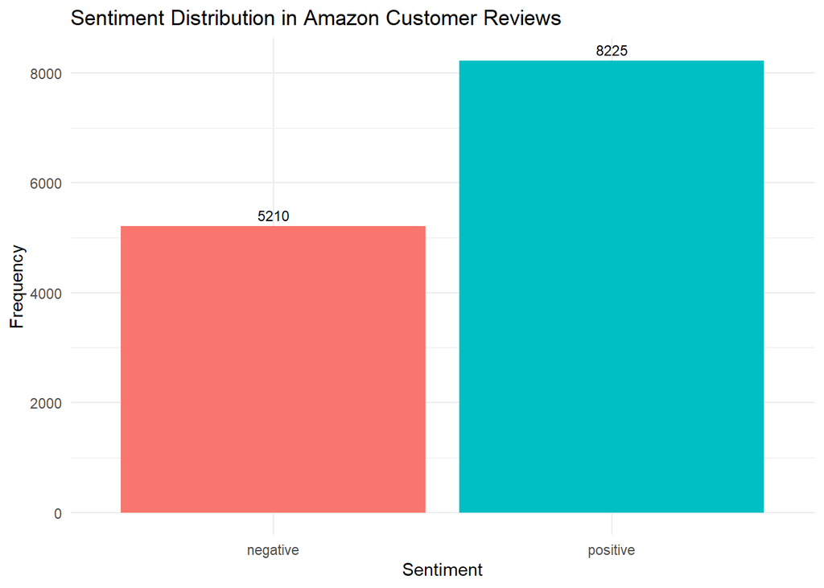

```r
# Visualize the sentiment distribution with value counts
library(ggplot2)
ggplot(sentiment_counts, aes(x = sentiment, y = n, fill = sentiment)) +
  geom_bar(stat = "identity") +
  geom_text(aes(label = n), vjust = -0.5, color = "black", size = 3) + # Add value counts
  labs(title = "Sentiment Distribution in Amazon Customer Reviews",
       x = "Sentiment",
       y = "Frequency") +
  theme_minimal() +
  theme(legend.position = "none")
```

### Word Clouds

```r
# Create wordclouds for positive and negative sentiments
positive_words <- amazon_reviews_sentiments %>%
  filter(sentiment == "positive") %>%
  count(word, sort = TRUE)
print(positive_words)
```

```
##                 word   n
## 1               like 530
## 2               love 459
## 3               well 258
## 4              great 247
## 5               good 239
## 6              loved 217
## 7               best 161
## 8               work 138
## 9              right 126
## 10            better 124
## 11              easy 110
## 12         recommend 101
## 13          favorite  99
## 14             loves  95
```

[output cut: 849 more lines]

```r
negative_words <- amazon_reviews_sentiments %>%
  filter(sentiment == "negative") %>%
  count(word, sort = TRUE)
print(negative_words)
```

```
##                   word  n
## 1                 hard 90
## 2                  bad 87
## 3                 plot 70
## 4                wrong 60
## 5                death 57
## 6               trauma 57
## 7               cancer 54
## 8                 dark 54
## 9                 fall 43
## 10             problem 39
## 11              issues 38
## 12                lost 38
## 13           difficult 37
## 14                fear 36
```

[output cut: 1250 more lines]

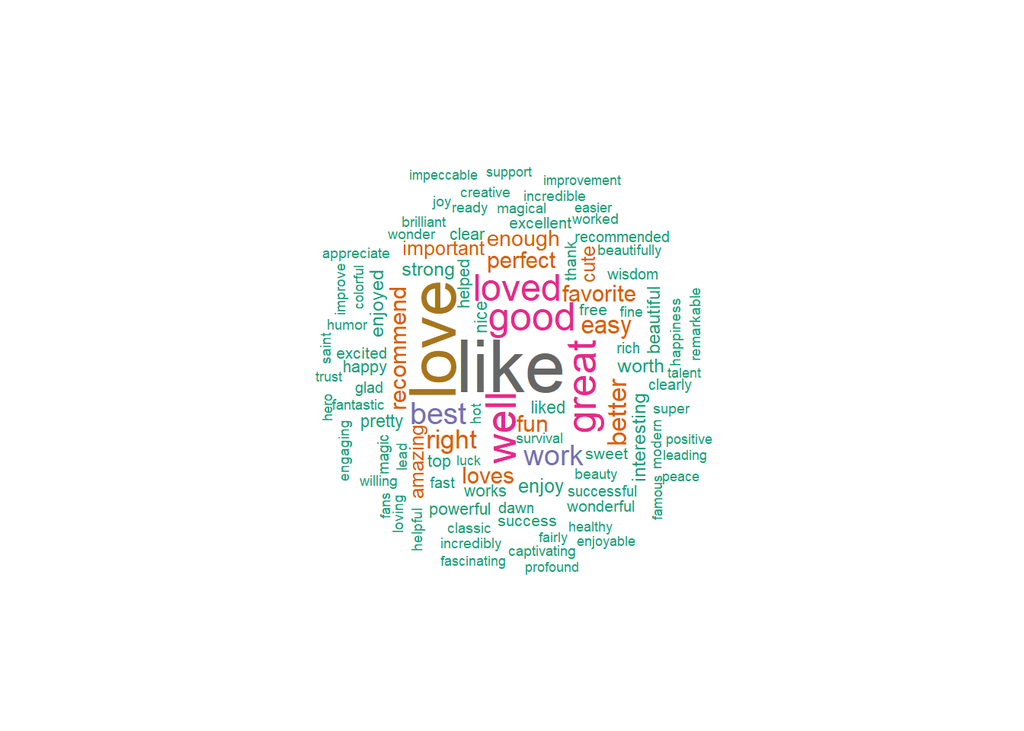

```r
# Plot wordcloud for positive sentiment
library(wordcloud)
wordcloud(positive_words$word, positive_words$n,
          max.words = 100, scale=c(3,0.5),
          colors = brewer.pal(8, "Dark2"),
          random.order = FALSE,
          rot.per = 0.35,
          main = "Wordcloud for Positive Sentiment")
```

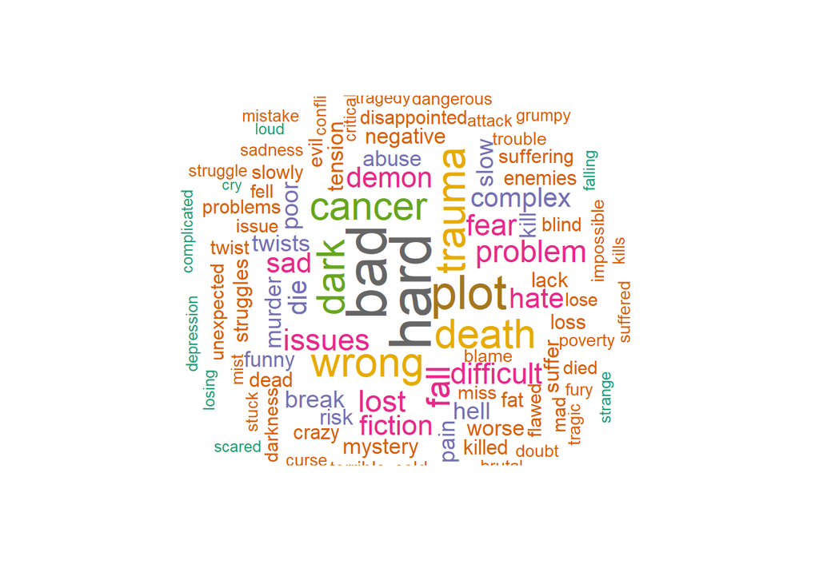

```r
# Plot wordcloud for negative sentiment
wordcloud(negative_words$word, negative_words$n,
          max.words = 100, scale=c(3,0.5),
          colors = brewer.pal(8, "Dark2"),
          random.order = FALSE,
          rot.per = 0.35,
          main = "Wordcloud for Negative Sentiment")
```

### Visualizing word frequencies

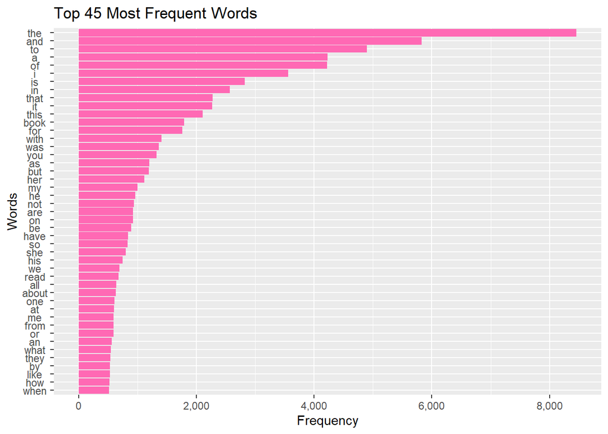

```r
# Visualizing word frequencies
word_freq <- amazon_reviews_tokens %>%
  count(word, sort = TRUE)

# Filter the top 100 most frequent words
word_freq_top_100 <- word_freq %>%
  filter(rank(desc(n)) <= 45)

# Sort words by frequency in descending order
word_freq_top_100 <- word_freq_top_100 %>%
  arrange(desc(n))

# Plotting with hotpink color
ggplot(word_freq_top_100, aes(x = n, y = reorder(word, n))) +
  geom_col(fill = "hotpink") +  # Changing the fill color to hotpink
  ylab("Words") +
  xlab("Frequency") +
  ggtitle("Top 45 Most Frequent Words") +
  theme(axis.text.y = element_text(hjust = 0.5)) +
  scale_x_continuous(labels = scales::comma)
```

### Visualizing word frequencies for positive and negative words

```r
# Filter the data for positive sentiment
positive_reviews <- amazon_reviews_sentiments %>%
  filter(sentiment == "positive")
#print(positive_reviews)

# Filter the data for negative sentiment
negative_reviews <- amazon_reviews_sentiments %>%
  filter(sentiment == "negative")
#print(negative_reviews)
```

```r
# Count word frequencies for positive reviews
word_freq_positive <- positive_reviews %>%
  count(word, sort = TRUE)
print(word_freq_positive)
```

```
##                 word   n
## 1               like 530
## 2               love 459
## 3               well 258
## 4              great 247
## 5               good 239
## 6              loved 217
## 7               best 161
## 8               work 138
## 9              right 126
## 10            better 124
## 11              easy 110
## 12         recommend 101
## 13          favorite  99
## 14             loves  95
```

[output cut: 849 more lines]

```r
# Count word frequencies for negative reviews
word_freq_negative <- negative_reviews %>%
  count(word, sort = TRUE)
print(word_freq_negative)
```

```
##                   word  n
## 1                 hard 90
## 2                  bad 87
## 3                 plot 70
## 4                wrong 60
## 5                death 57
## 6               trauma 57
## 7               cancer 54
## 8                 dark 54
## 9                 fall 43
## 10             problem 39
## 11              issues 38
## 12                lost 38
## 13           difficult 37
## 14                fear 36
```

[output cut: 1250 more lines]

```r
# Combine the top 45 most frequent words for positive and negative sentiments
word_freq_top_positive <- word_freq_positive %>%
  filter(rank(desc(n)) <= 45)
print(word_freq_top_positive)
```

```
##           word   n
## 1         like 530
## 2         love 459
## 3         well 258
## 4        great 247
## 5         good 239
## 6        loved 217
## 7         best 161
## 8         work 138
## 9        right 126
## 10      better 124
## 11        easy 110
## 12   recommend 101
## 13    favorite  99
## 14       loves  95
```

[output cut: 30 more lines]

```r
word_freq_top_negative <- word_freq_negative %>%
  filter(rank(desc(n)) <= 45)
print(word_freq_top_negative)
```

```
##         word  n
## 1       hard 90
## 2        bad 87
## 3       plot 70
## 4      wrong 60
## 5      death 57
## 6     trauma 57
## 7     cancer 54
## 8       dark 54
## 9       fall 43
## 10   problem 39
## 11    issues 38
## 12      lost 38
## 13 difficult 37
## 14      fear 36
```

[output cut: 30 more lines]

```r
# Sort words by frequency in descending order for both positive and negative sentiments
word_freq_top_positive <- word_freq_top_positive %>%
  arrange(desc(n))
print(word_freq_top_positive)
```

```
##           word   n
## 1         like 530
## 2         love 459
## 3         well 258
## 4        great 247
## 5         good 239
## 6        loved 217
## 7         best 161
## 8         work 138
## 9        right 126
## 10      better 124
## 11        easy 110
## 12   recommend 101
## 13    favorite  99
## 14       loves  95
```

[output cut: 30 more lines]

```r
word_freq_top_negative <- word_freq_top_negative %>%
  arrange(desc(n))
print(word_freq_top_negative)
```

```
##         word  n
## 1       hard 90
## 2        bad 87
## 3       plot 70
## 4      wrong 60
## 5      death 57
## 6     trauma 57
## 7     cancer 54
## 8       dark 54
## 9       fall 43
## 10   problem 39
## 11    issues 38
## 12      lost 38
## 13 difficult 37
## 14      fear 36
```

[output cut: 30 more lines]

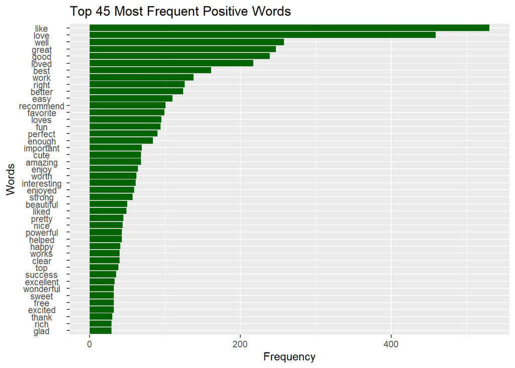

```r
# Plot for positive words
plot_positive <- ggplot(word_freq_top_positive, aes(x = n, y = reorder(word, n))) +
  geom_col(fill = "darkgreen") +
  ylab("Words") +
  xlab("Frequency") +
  ggtitle("Top 45 Most Frequent Positive Words") +
  theme(axis.text.y = element_text(hjust = 0.5)) +  # Center y-axis labels
  scale_x_continuous(labels = scales::comma)  # Add comma separators to x-axis labels

# Plot for negative words
plot_negative <- ggplot(word_freq_top_negative, aes(x = n, y = reorder(word, n))) +
  geom_col(fill = "skyblue") +
  ylab("Words") +
  xlab("Frequency") +
  ggtitle("Top 45 Most Frequent Negative Words") +
  theme(axis.text.y = element_text(hjust = 0.5)) +  # Center y-axis labels
  scale_x_continuous(labels = scales::comma)  # Add comma separators to x-axis labels

# Display the plots separately
plot_positive
```

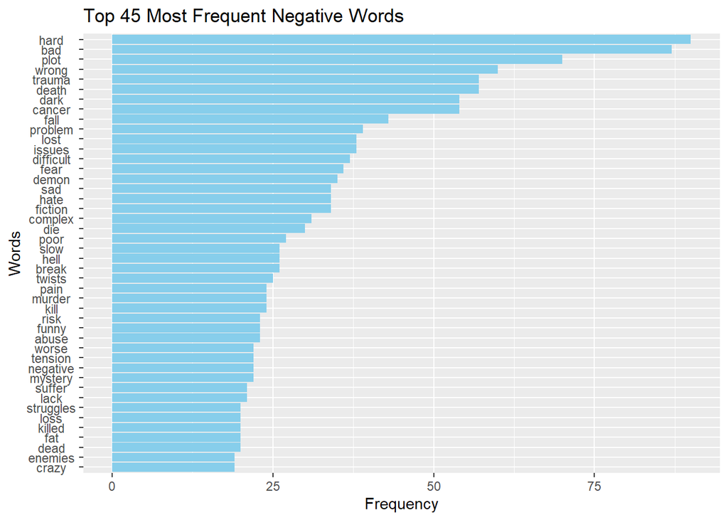

```r
plot_negative
```

### Conclusion

Through conducting sentiment analysis on Amazon’s Top 100 Bestselling Book reviews, I aimed to provide valuable insights into customer opinions and preferences in the realm of popular literature. Based on my analysis, it was evident that Amazon Book Reviewers mostly wrote positive reviews rather than negative ones. This analysis will not only benefit publishers and authors but also assist readers in making informed decisions about their book selections.